# Nonparametric Regression

73-374 Econometrics II

## Today

- Nonparametric Estimation
  - Local Constant Regression
  - Local Linear Regression
  - Kernels
- Not in your textbooks
  - But important part of modern data analysis
- Reasonably accessible reference
  - Ch 20 of Bruce Hansen’s “Econometrics” textbook
  - http://www.ssc.wisc.edu/~bhansen/econometrics/

## Nonlinear to nonparametric methods

- Model: $Y=f(X)+u$
- Interested in Conditional Expectation Function CEF
  - $E[Y|X=x]=f(x)$
- If $f(x)$ linear, estimate by OLS
- If $f(x)$ nonlinear, with known form, estimate by nonlinear least squares
- If $f(x)$ has completely unknown form, estimate by **nonparametric regression**
- No longer have $f(X,\theta)$
  - Not looking for coefficients or other parameters
  - Hence *non*-parametric
- Alternate view
  - $f(x)$ *is* the parameter: one value for every $x$
  - “Nonparametric” can mean *infinite* number of parameters

## Local Estimation: Discrete case

- How to estimate $f(x)$ without knowing form?
  - Many ways, one way very simple
- Estimate $E[Y|X=x]$ by average of Y when $X=x$
  $$\widehat{f}(x)=\frac{\sum_{i=1}^{n}Y_i1\{X_i=x\}}{\sum_{i=1}^{n}1\{X_i=x\}}$$
- This is a “local” sample average
- Note that “sample size” for average is # of X’s at a point $n_x=\sum_{i=1}^{n}1\{X_i=x\}$
  - Much smaller than total # of observations
  - $Var(\widehat{f}(x)|X)$ proportional to $\frac{1}{n_x}$ instead of $\frac{1}{n}$
- Works when $X$ has discrete distribution, takes on only small number of values
- Doesn’t work when $X$ has continuous distribution
  - At any $x$, likely to have 1 or 0 observations: can’t take average

## Example: Education vs. log Wages (Code 1)

```r
#Load Libraries for nonparametric estimation
#If not installed, uncomment to install
# "np" library for nonparametrics
#install.packages("np",
#  repos="http://cran.us.r-project.org")
library(np)
#Load data on Wages
library(foreign)
wagedat<-read.dta(
  "http://fmwww.bc.edu/ec-p/data/wooldridge/wage1.dta")
#Run nonparametric regression of wages on education
#Use local average estimator
# See np help files for syntax
wagebw<-npregbw(ydat=wagedat$lwage,
        xdat=ordered(wagedat$educ))
```

## Example: Education vs. log Wages (Code 2)

```r
#Pretty up Names
wagebw$xnames<-"Years of Education"
wagebw$ynames<-"Log Wage"
# Plot with standard error estimates
plot(wagebw, plot.errors.method="asymptotic",
     main="Wages vs Education")
## Add data points
points(wagedat$educ,wagedat$lwage,
       cex=0.2,col="blue")
```

## Example: Education vs. log Wages again

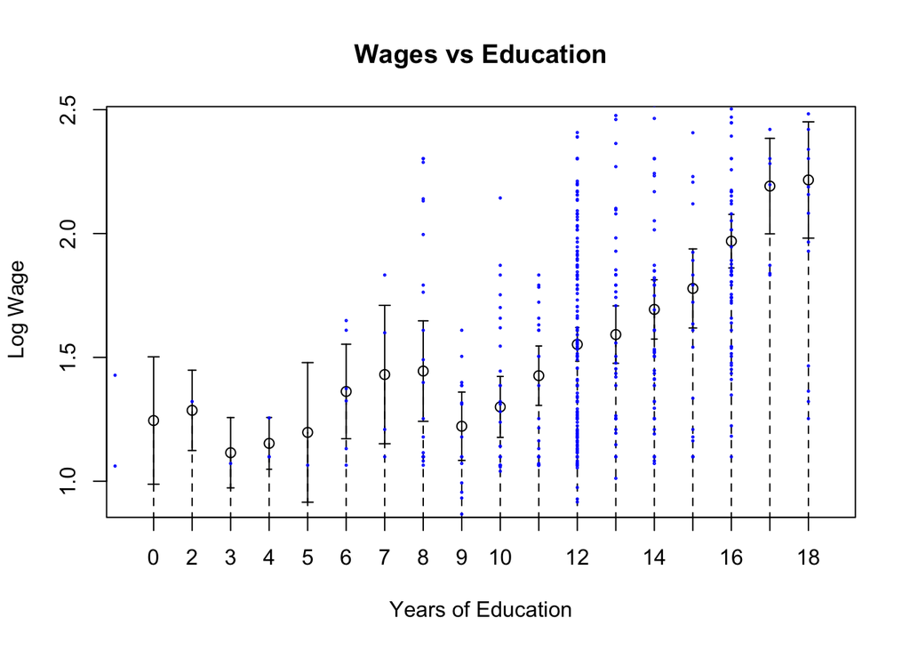

## Local Estimation: Continuous Case

- Suppose $f(x)$ continuous, maybe also differentiable
- Then $Y_i$ when $X_i$ near $x$ also tell us about $f(x)$
- Take average of $Y_i$ in small area (say, of width $h$) around $x$
  $$\widehat{f}(x)=\frac{\sum_{i=1}^{n}Y_i1\{X_i\in[x-\frac{h}{2},x+\frac{h}{2}]\}}{\sum_{i=1}^{n}1\{X_i\in[x-\frac{h}{2},x+\frac{h}{2}]\}}$$
- Another local average, this time over $n_x=\sum_{i=1}^{n}1\{X_i\in[x-\frac{h}{2},x+\frac{h}{2}]\}$ data points
- Can take average at any point $x$, getting estimate of function $f(x)$ by moving the “window”
- Because data is shared between points $x$, $\widehat{f}(x)$ is smoothed out
- Hence, procedure is called a “smoother”
- Also called **local constant** regression, because it is exact if $f(x)$ constant in neighborhood
- Sometimes also **Nadaraya-Watson** regression

## Principle: Bias-Variance Tradeoff

- Making width $h$ larger raises sample size
  - Reduces variance of estimate
- But larger $h$ means including $x$ values where $f(x)$ not exactly the same as at desired $x$
  - Estimate is biased
- By continuity, as $x^\prime\rightarrow x$, $f(x^\prime)\rightarrow f(x)$
- Can reduce bias by making $h$ smaller as sample size grows
- Idea: pick $h$ big enough so average contains enough data points, but small enough so bias is limited
  - If $h\rightarrow 0$ bias disappears
  - If $h$ shrinks slowly as sample grows, neighborhood can contain more and more data, and so variance will also shrink
- Obtain a *consistent* estimate of $f(x)$ at each point
- Cost is that by shrinking $h$, sample size used at each point has to grow slower than $n$
  - Variance of nonparametric estimator goes to 0 at **rate** $nh$ instead of $n$

## Local Linear Regression

- If $f(x)$ differentiable, it has a slope at each point
- Reduce bias due to points near x by controlling the slope
- Run linear regression on points in width $h$ neighborhood of $x$
- Even if $f(x)$ nonlinear, at any point line is a good approximation
- Writing this down as a formula, get $(\widehat{\beta}_0(x),\widehat{\beta}_1(x))$
  $$=\underset{(\beta_0,\beta_1)}{\arg\min}\sum_{i=1}^{n}1\{X_i\in[x-\frac{h}{2},x+\frac{h}{2}]\}(Y_i-\beta_0-\beta_1(X_i-x))^2$$
- Constant term $\widehat{\beta_0}(x)$ is **local linear** estimator of $f(x)$
- For consistency, let $h$ go to 0 to reduce bias since not exactly linear, but slowly so variance also falls
- $\widehat{\beta}_1(x)$ provides consistent estimate of derivative of $f(x)$
- Can show that local constant regression formula same as
  $$\underset{\beta_0}{\arg\min}\sum_{i=1}^{n}1\{X_i\in[x-\frac{h}{2},x+\frac{h}{2}]\}(Y_i-\beta_0)^2$$

## Example: Wages and Education, Smoothed (Code 1)

```r
#Estimate using package "np", one of many R packages
#Local Constant Estimator (regtype="lc")
#Use arbitrary width h=2 instead of computer supplied one
# (bws=c(2),bandwidth.compute=FALSE)
#To estimate by formula above, use ckertype="uniform"
localconstantwage<-npregbw(ydat=wagedat$lwage,
  xdat=wagedat$educ, regtype="lc",bws=c(2),
  bandwidth.compute=FALSE, ckertype="uniform")))
#Local Linear estimator
#Same, but local linear (regtype="ll")
locallinearwage<-npregbw(ydat=wagedat$lwage,
    xdat=wagedat$educ,regtype="ll",bws=c(2),
    bandwidth.compute=FALSE, ckertype="uniform")))
```

## Example: Wages and Education, Smoothed (Code 2)

```r
#Pretty up Names
localconstantwage$xnames<-"Years of Education"
localconstantwage$ynames<-"Log Wage"
# Plot
plot(localconstantwage, main=
  "Wage vs Education: Local Constant Estimator, h=2")
points(wagedat$educ,wagedat$lwage,cex=0.2,col="blue")
```

## Example: Wages and Education, Smoothed (Code 3)

```r
#Pretty up Names
locallinearwage$xnames<-"Years of Education"
locallinearwage$ynames<-"Log Wage"
# Plot
plot(locallinearwage, main=
    "Wage vs Education: Local Linear Estimator, h=2")
points(wagedat$educ,wagedat$lwage,cex=0.2,col="blue")
```

## Example: Wages and Education, Smoothed

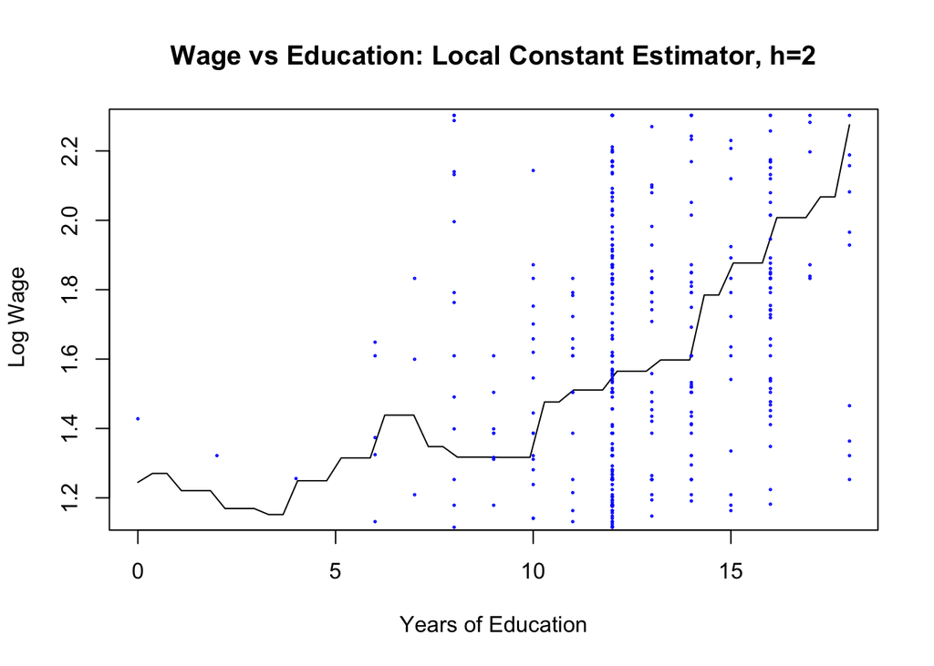

## Example: Wages and Education, Smoothed

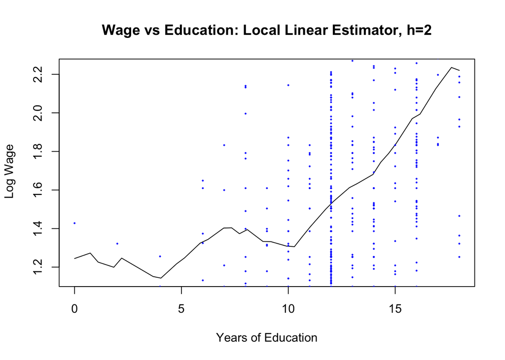

## Choosing the “bandwidth”

- In practice, $h$, called the “bandwidth” matters a lot
- At $h=\infty$, local constant estimator is just mean of Y, local linear estimator is just OLS
- At $h=0$, local constant estimator is just average at a point
- Bias-variance tradeoff tells us where it should be
- If just predicting, goal is often to minimize mean squared error loss
  $$E[(\widehat{f}(x)-f(x))^2] = E[(\widehat{f}(x))^2]-2E[\widehat{f}(x)]f(x)+f^2(x)$$
  $$= (E[(\widehat{f}(x))^2]-E[\widehat{f}(x)]^2)+(E[\widehat{f}(x)]^2-2E[\widehat{f}(x)]f(x)+f^2(x))$$
  $$= Var(\widehat{f}(x))+(Bias(\widehat{f}(x)))^2$$
- Variance decreases with $h$, Bias increases

## Correct Rate

- Variance is variance of an average (or OLS) on $nh$ data points
  - Proportional to $\frac{1}{nh}$
- Bias depends on how smooth $f(x)$ is
- If twice differentiable, can Taylor expand
  - $f(x+h)=f(x)+f^\prime(x)h+Remainder*h^2$
  - Remainder in local linear approximation proportional to $h^2$
- MSE(h)=$\text{Bias}^2$ + Variance is $c_1*h^4+c_2*\frac{1}{nh}$
- Minimize by setting derivative to 0
  - $4c_1*h^3-c_2*\frac{1}{nh^2}=0$
- $h$ proportional to $n^{-1/5}$ gives smallest error
- Plugging back in, error proportional to $n^{-4/5}$
- Compare to linear regression case
  - Bias=0, variance proportional to $n^{-1}$
- Cost of not knowing true form is needing more data
- If goal is not prediction, may care more about bias than variance, so choose smaller $h$

## Cross Validation

- $h$ “proportional to” $n^{-1/5}$ result not so useful in practice
  - Don’t know constant of proportionality
- In practice, choose $h$ by minimizing a proxy for MSE
  - Split data into parts
  - For every possible $h$
    - Estimate $\widehat{f}(x)$ on part 1 using $h$
    - Evaluate sample sum of squared errors on part 2
  - Choose $h$ that gives smallest sum of squares
- Can get even better estimate by flipping parts 1 and 2, using average of out of sample error to get MSE, minimizing the average
- Even better, split in K parts, estimate on K-1, evaluate on last, and average K times
- Called **K-fold cross validation**
- K can be as large as $n$: called **leave-one-out cross-validation**
- Done automatically by standard local regression software

## Aside: Code

- Many $R$ programs will do nonparametric regression
  - **np** library, **ksmooth** in **stats**, **locpoly**
- **np** library has most options, but because of this a bit harder to use
  - Cross validation to choose bandwidth by **npregbw** command
  - Local constant or linear regression by **npreg**

## Example with cross-validated bandwidth (Code)

```r
#Local Linear estimator with cross validated bandwidth
#Cross-validation is default, so no extra command
cvwagereg<-npregbw(ydat=wagedat$lwage,
    xdat=wagedat$educ,regtype="ll",
    ckertype="uniform")))
#Display Results
summary(cvwagereg)
```

## Example with cross-validated bandwidth

```
##
## Regression Data (526 observations, 1 variable(s)):
##
## Regression Type: Local-Linear
## Bandwidth Selection Method: Least Squares Cross-Validation
## Bandwidth Type: Fixed
## Objective Function Value: 0.2228431 (achieved on multistart 1)
##
## Exp. Var. Name: wagedat$educ Bandwidth: 1.020967 Scale Factor: 2.410932
##
## Continuous Kernel Type: Uniform
## No. Continuous Explanatory Vars.: 1
## Estimation Time: 0.349 seconds
```

## Example: Wages and Education, Optimally Smoothed (Code)

```r
#Pretty up Names
cvwagereg$xnames<-"Years of Education"
cvwagereg$ynames<-"Log Wage"
# Plot
plot(cvwagereg, main=
  "Wage vs Education: Local Linear Estimator, optimal h")
points(wagedat$educ,wagedat$lwage,cex=0.2,col="blue")
```

## Example: Wages and Education, Optimally Smoothed

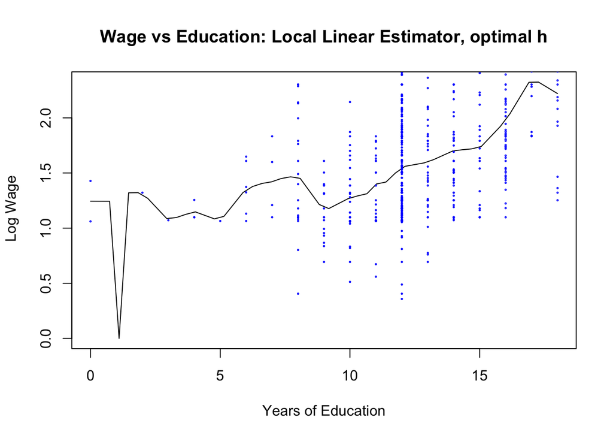

## Kernels

- As described, local methods used a hard cutoff to decide which points are used to give information near $x$
  - Weight 1 if within $h/2$ of $x$, 0 otherwise
- Can get less jumpy results by using a soft cutoff
  - Weight $K(u)$ which is smooth function of $u$, distance of $X_i$ from x
  - Called a **Kernel**
- Any function which gives higher weight to near points can work
- Standard to use a density which integrates to 1
  - Like a Gaussian $K(u)=\frac{1}{\sqrt{2\pi}}exp(-u^2/2)$
- Bandwidth enters as $K(\frac{u}{h})$
- Smaller bandwidth means weight more peaked near center
- Estimator becomes
  $$(\widehat{\beta}_0(x),\widehat{\beta}_1(x))=\underset{(\beta_0,\beta_1)}{\arg\min}\sum_{i=1}^{n}K(\frac{X_i-x}{h})(Y_i-\beta_0-\beta_1(X_i-x))^2$$

## Kernel Regression

- Using kernel weighting function changes none of practical issues
- $1\{X_i\in[x-\frac{h}{2},x+\frac{h}{2}]\}$ corresponds to $K(u)=1\{u\leq\frac{1}{2}\}$
  - Uniform density, sometimes called “Boxcar kernel”
- Bias and variance calculations similar
- Now depend on function $K(u)$
- Usually rates are the same ($n^{-4/5}$ if $f(x)$ twice differentiable), but can sometimes get better constant by using different kernel

## Multivariate Nonparametric Regression

- If $X$ is a vector, same principles apply
- $f(x_1,x_2)$ can be estimated by local version of multivariate regression
- Difference is “local” means close in both $x_1$ and $x_2$ directions
- Don’t need to choose same bandwidth for each
- Can do $K(u_1/h_1,u_2/h_2)$
- E.g. $1\{X_{1i}\in[x_1-\frac{h_1}{2},x_1+\frac{h_1}{2}]\}1\{X_{2i}\in[x_2-\frac{h_2}{2},x_2+\frac{h_2}{2}]\}$
- Common choice is product of 1d kernels, e.g. $K(u_1/h_1,u_2/h_2)=K(u_1/h_1)K(u_2/h_2)$
- Local linear regression now weighted multivariate regression

## Curse of Dimensionality

- As dimension $d$ of $X$ grows, area in a (hyper)-cube of constant side length declines exponentially in $d$
- Number of points in interval of length $h$ in one direction becomes very small
- Need much larger width for same variance, but then bias grows
- Result is rate of convergence depends on $d$.
- Can show, with 2 derivatives in each dimension, MSE declines at rate $n^{-4/(4+d)}$
- Means that if $d$ bigger than a handful, need a huge amount of data to get precise estimates
- This is not a problem with estimator: just difficult in general

## Example: Wages vs Education, Experience, and Tenure (Code 1)

```r
#Local Linear estimator with cross validated bandwidth
#Cross-validation is default, so no extra command
multiplenpreg<-npregbw(formula=wagedat$lwage~
  wagedat$educ + wagedat$exper +
  wagedat$tenure,regtype="ll")))
```

## Example: Wages vs Education, Experience, and Tenure (Code 2)

```r
#Pretty up Names
multiplenpreg$xnames<-c("Years of Education",
  "Years of Experience","Years in Current Job")

multiplenpreg$ynames<-"Log Wage"
#Display info
(summary(multiplenpreg))
```

## Example: Wages vs Education, Experience, and Tenure

[output not shown]

## Wage vs Education, Experience, Tenure at median of others (Code)

```r
# Plot
plot(multiplenpreg, main= "Wage vs Covariates")
```

## Wage vs Education, Experience, Tenure at median of others

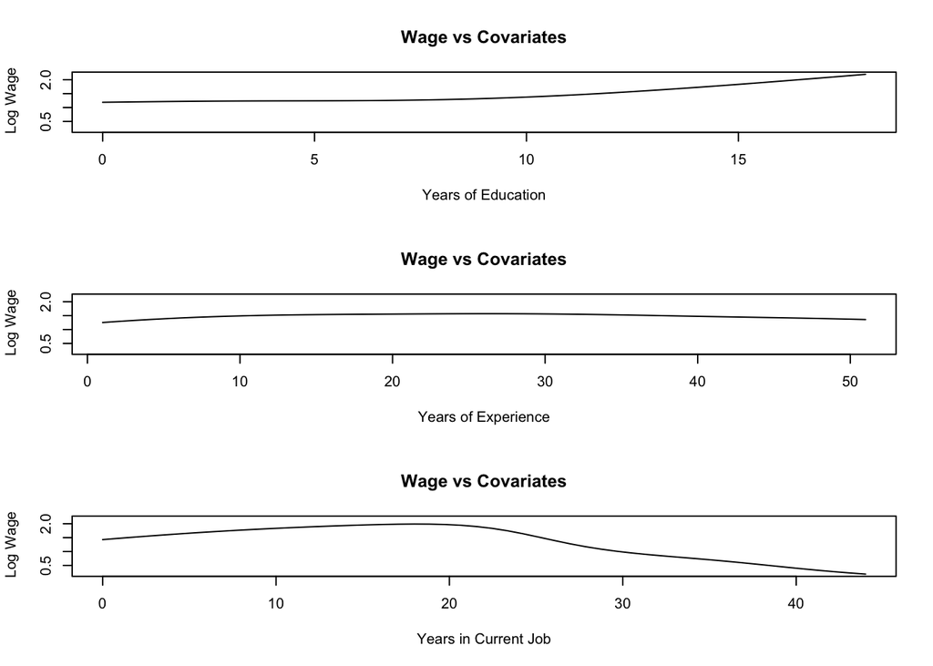

## Summary

- By estimating average or regression near a point $x$, can obtain estimates of conditional expectation function without knowing functional form
- Need to choose how close is “near”: trade off bias and variance
- Cross validation can give good choice in practice
- Not knowing form means less precise estimates, slower convergence to truth
  - Not a disadvantage of these methods,
  - If form unknown, OLS and NLLS converge only to best predictor in their class
  - This is biased estimate of CEF

## Next Class

- Regression Discontinuity
  - An application of nonparametric regression to causal inference
  - Angrist and Pischke Chapter 4

## Bonus Slide: Alternative: Series Regression

- Instead of local regression, could just use OLS with many nonlinear terms
- **Series regression**
- Polynomials, piecewise polynomials (splines), etc
- OLS only unbiased if CEF truly in class
- Otherwise, has bias term
- Can take it to 0 by using more and more functions with sample
- Tradeoff is variance goes up
  - To see this, note finite sample variance has degrees of freedom correction for # of regressors
- Get similar performance to kernels if functions and number chosen optimally
- Can use cross-validation to pick order
- Do not use standard OLS inference: rate is slower since not letting variance go to 0 as quickly

## Bonus Slide: Higher Order Regression

- If function $f(x)$ very smooth, can do a bit better than $n^{-4/5}$
- Idea is that you can go to higher order in Taylor expansion, try to exactly cancel out those terms
- Do this by using quadratic function in local regression, or cubic, etc
- Called “local polynomial” regression
- Interpolates between series and local methods: capture nonlinearity both through window and by functional form
- Since degree of smoothness not known, and adding terms raises variance when reducing bias, only sometimes helpful
- Can achieve similar effect with special choices of $K(u)$ called higher order kernels